# College Scoreboard

Shan Chen

5/3/2020

```r
data.df <- read.csv("Colleges2015.csv")
dim(data.df)
```

```
## [1] 135  15
```

```r
numCol <- ncol(data.df)
datascore.df <- data.df[,1:15]
schoolNames <- data.df[,1]
eventNames <- colnames(data.df)
data.mat <- data.matrix(datascore.df)
rownames(data.mat) <- schoolNames
mod.pca <- prcomp(data.mat,scale=T)
summary(mod.pca)
```

```
## Importance of components:
##                           PC1    PC2    PC3     PC4     PC5     PC6     PC7
## Standard deviation     2.5091 1.6526 1.1158 1.08753 0.97488 0.86406 0.82402
## Proportion of Variance 0.4197 0.1821 0.0830 0.07885 0.06336 0.04977 0.04527
## Cumulative Proportion  0.4197 0.6018 0.6848 0.76362 0.82698 0.87675 0.92202
##                            PC8    PC9    PC10   PC11   PC12    PC13    PC14
## Standard deviation     0.57932 0.4484 0.40225 0.3794 0.3376 0.29575 0.25924
## Proportion of Variance 0.02237 0.0134 0.01079 0.0096 0.0076 0.00583 0.00448
## Cumulative Proportion  0.94439 0.9578 0.96858 0.9782 0.9858 0.99161 0.99609
##                           PC15
## Standard deviation     0.24211
## Proportion of Variance 0.00391
## Cumulative Proportion  1.00000
```

As we can see from summary, the first two composes about 60% of the Variances.

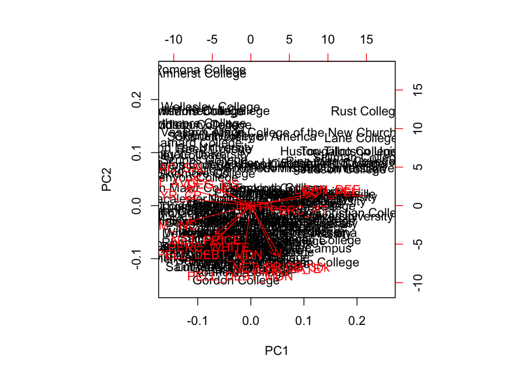

```r
biplot(mod.pca)
```

### Building a better biplot

Pull off the rotated scores. These are the points in the biplot.

```r
scoresRotated <- mod.pca$x
rotation.mat <- mod.pca$rotation
```

Put the PCA info into data frames

```r
scoresRotated.df <- data.frame(scoresRotated)
scoresRotated.df$names <- schoolNames
rotation.df <- data.frame(rotation.mat)
rotation.df$events <- eventNames
```

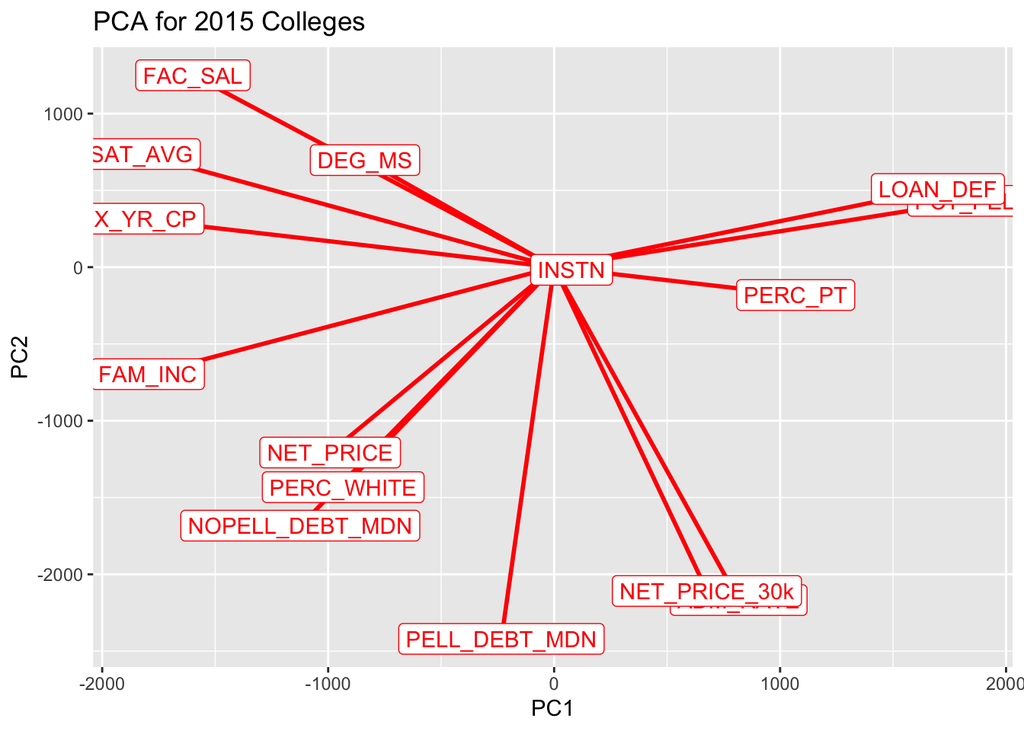

```r
sc <- 5000 ## get everything on the same scale
scoresRotated.df %>%
  ggplot()+
  ## Rotated athlete scores
  geom_point(aes(PC1,PC2))+
  ## Add the loadings,  these are just the coordinates in the PC1 and PC2 vectors
  geom_segment(data=rotation.df,
             aes(x=0,y=0,xend=sc*PC1,yend=sc*PC2),size=1,color="red")+
  geom_label(data=rotation.df,
              aes(sc*PC1,sc*PC2,label=events),color="red")+
  labs(title="PCA for 2015 Colleges")
```

Seems like degree in MS is strongly correlated with good salary, SAT avg and 6 year completion rate. White percentage correleated with net price, no pell debt median. Parttime rate is strongly associated with loan.

#K means

```r
data1.mat <- data.matrix(scoresRotated.df[c("PC1","PC2")])
```

```r
numClusters <- 3
mod.km <- kmeans(data.mat,centers=numClusters)
```

Note: we can add an extra parameter “nstart” to indicate how many times to run the clustering. This can be helpful to account for variances in the outcome due to the random start. If nstart>1, the algorithm will try to find the most common clustering outcome.

Here’s what you get..

```r
names(mod.km)
```

```
## [1] "cluster"      "centers"      "totss"        "withinss"     "tot.withinss"
## [6] "betweenss"    "size"         "iter"         "ifault"
```

For example, you can access the clusters and centers of mass.

```r
mod.km$centers
```

```
##      INSTN  ADM_RATE  SAT_AVG     DEG_MS PERC_WHITE    PERC_PT NET_PRICE
## 1 67.13559 0.6371407 1107.102 0.02346271  0.6586356 0.02623051  21655.27
## 2 66.73585 0.5050189 1261.170 0.02983208  0.6859528 0.01079245  25963.68
## 3 72.60870 0.5650913  923.087 0.01051304  0.2881522 0.07734348  17699.48
##   NET_PRICE_30k  FAC_SAL  PCT_PELL SIX_YR_CP   LOAN_DEF PELL_DEBT_MDN
## 1      16223.03 7330.068 0.3296508 0.6268746 0.04774576      19817.21
## 2      14916.08 9205.679 0.1853962 0.8103264 0.02256604      21633.94
## 3      16072.48 6172.391 0.6133478 0.4357478 0.11730435      18009.43
##   NOPELL_DEBT_MDN   FAM_INC
## 1        17342.52  74130.68
## 2        19572.86 104851.29
## 3        12958.24  39231.83
```

```r
mod.km$cluster
```

```
##          Birmingham Southern College                       Judson College
##                                    1                                    3
##                     Stillman College                         Lyon College
##                                    3                                    1
##                      Hendrix College          Ouachita Baptist University
##                                    2                                    1
##          San Diego Christian College            Claremont McKenna College
##                                    3                                    2
##                  Harvey Mudd College                   Occidental College
##                                    2                                    2
##                Pacific Union College                       Pomona College
##                                    1                                    1
##                      Scripps College                   Simpson University
##                                    2                                    3
##               Thomas Aquinas College                     Westmont College
##                                    2                                    2
##                     Whittier College                       Eckerd College
##                                    1                                    2
##                        Berry College                    Morehouse College
##                                    1                                    1
##                Oglethorpe University                   Shorter University
##                                    1                                    3
##                      Spelman College         Illinois Wesleyan University
##                                    1                                    2
##                     Monmouth College                      Wheaton College
##                                    1                                    2
##                    DePauw University                       Goshen College
##                                    2                                    1
##                      Hanover College                   Holy Cross College
##                                    1                                    1
##                 Saint Mary's College                       Wabash College
##                                    2                                    2
##                      Central College                          Coe College
##                                    1                                    1
##                      Cornell College                     Grinnell College
##                                    2                                    2
##                       Luther College                      Simpson College
##                                    2                                    1
##                     Wartburg College                       Centre College
##                                    2                                    2
```

[output cut: 81 more lines]

```
##                                    2                                    1
##                  Sweet Briar College            Virginia Wesleyan College
##                                    1                                    1
##        Washington and Lee University                      Whitman College
##                                    2                                    2
##                      Bethany College                     Carthage College
##                                    1                                    2
##                    Northland College                        Ripon College
##                                    1                                    1
##                Saint Norbert College           Wisconsin Lutheran College
##                                    2                                    1
##           Soka University of America                 Ave Maria University
##                                    3                                    2
##                   The King's College
##                                    1
```

```r
## Search up to M
M <- 15
twissVals <- numeric(M)
for(k in 1:M){
    mod.kmeans <- kmeans(scoresRotated.df[c("PC1","PC2")],centers=k,nstart=25)
    twissVals[k] <- mod.kmeans$tot.withinss
}
```

What do we have

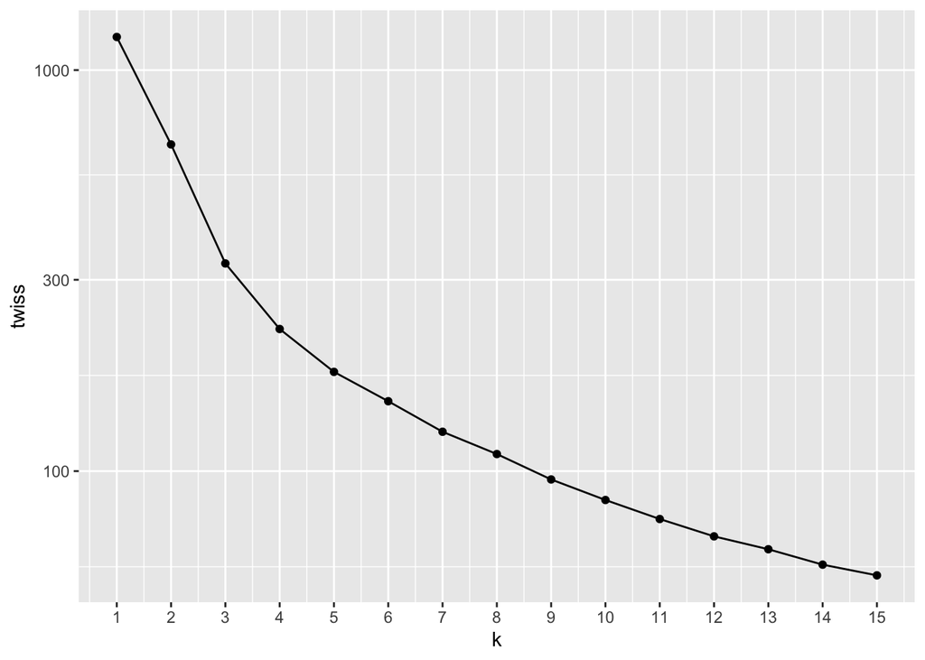

```r
data.frame(k=1:M,
           twiss=twissVals) %>%
    ggplot()+
    geom_point(aes(k,twiss))+
    geom_line(aes(k,twiss))+
  scale_y_log10()+
    scale_x_continuous(breaks=1:M)
```

In general, this elbow plot can help identify the optimal k. In practice, the elbow can be hard to precisely identify. Close enough is good enough. Of course, in practice, you would use some sort of train/test to see if the elbow persists.

## Using the factoextra package

The factoextra package has some tools to make this easier to see/ For example, it will create the TWSS plot

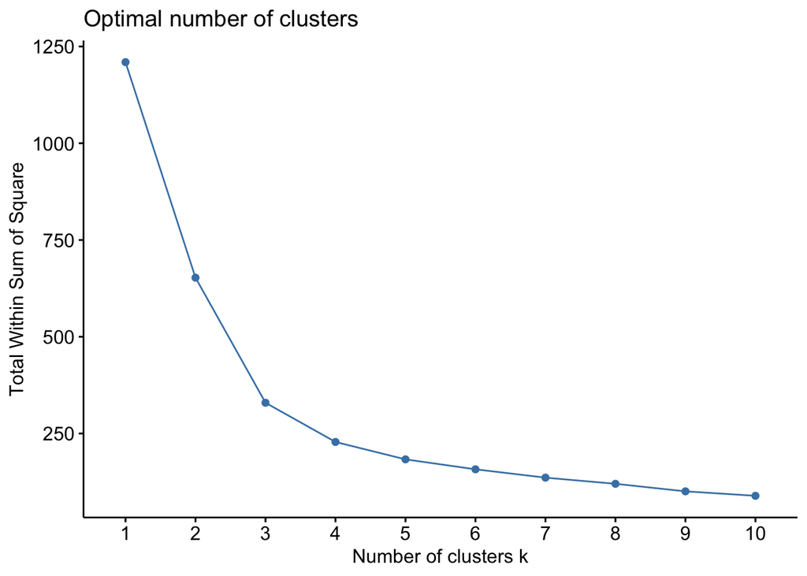

```r
library(factoextra)
data2.df <- scoresRotated.df[c("PC1","PC2")]
fviz_nbclust(data2.df,kmeans,method="wss")
```

Visualizing the clustering

```r
K <- 10
mod.km <- kmeans(data2.df,K,nstart=25)
data2.df$cluster <- factor(mod.km$cluster)
```

The plot of the points and their clusters

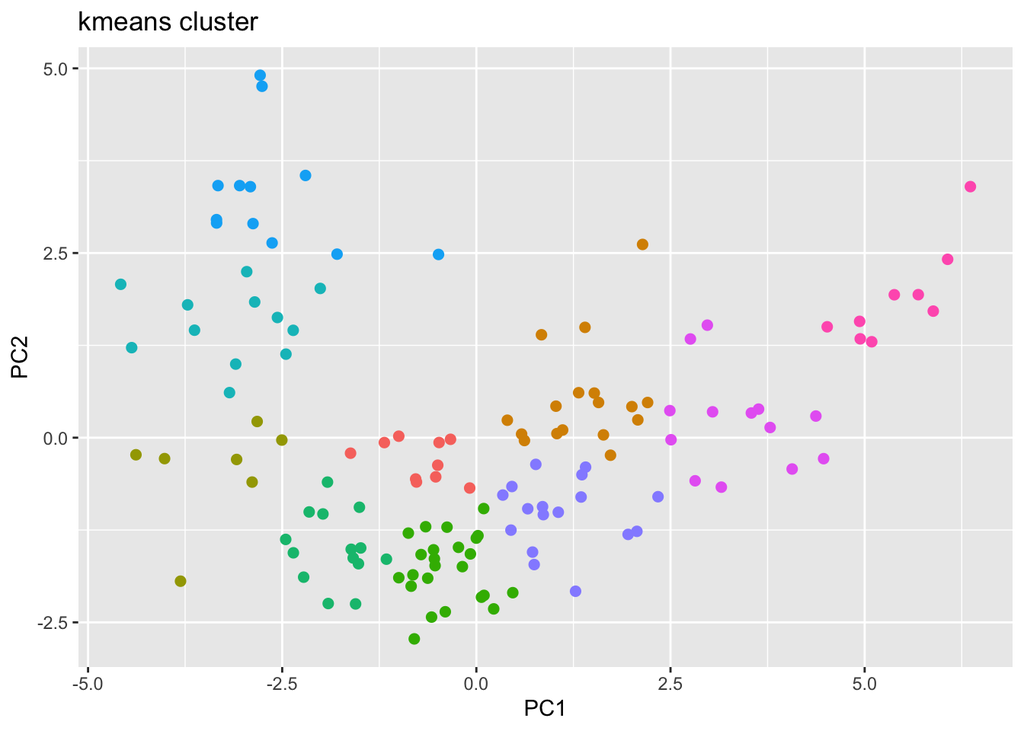

```r
ggplot(data2.df,aes(PC1,PC2,color=cluster))+
    geom_point(size=2)+
    guides(color=F)+
    ggtitle("kmeans cluster")
```

Here is how factoextra does it.

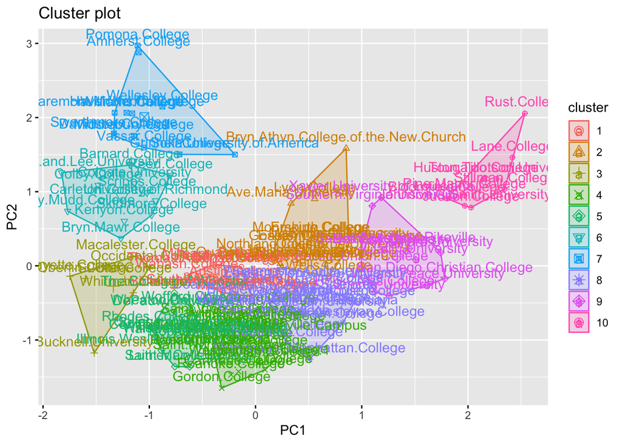

```r
fviz_cluster(mod.km,data=data2.df[,1:2])
```